# Pure Python Implementation of K-Medoids

In this project, we will utilize base python and numpy to create a comprehensive explaination and implementation of the k-medoids algorithim. We will use image compression as the primary movtivating example.

### $K$-medoids

The basic $K$-means algorithim works in Euclidean space for computing distance between data points as well as for updating centroids by arithmetic mean. Sometimes, however, the data-set may work better with other distance measures. It is sometimes even impossible to compute arithmetic mean if a feature is categorical, e.g, gender or nationality of a person. However, with $K$-medoids, you can choose a representative data point for each cluster instead of computing their average. Please note that $K$-medoid is different from generalized $K$-means: Generalized $K$-means still computes centre of a cluster is not necessarily one of the input data points (it is a point that minimizes the overall distance to all points in a cluster in a chosen distance metric). K-medoids on the other hand will always select a medoid that is an acutal point within the cluster.

Given $m$ data points $\text x^i (i = 1, \ldots, m)$, $K$-medoids clustering algorithm groups them into $K$ clusters by minimizing the distortion function $J = \sum_{i=1}^m \sum_{j=1}^k r^{ij} D(\text x^i, \mu^j)$, where $D(\text x, \text y)$ is a distance measure between two vectors $\text x$ and $\text y$ in same size (in case of $K$-means, $D(x, y) = \| \text x - \text y \|^2$), $\mu^j$ is the center of $j$-th cluster; and $r^{ij} = 1$ if $\text x^n$ belongs to the $k$-th cluster and $r^{ij} = 0$ otherwise. In this project, we will use the following iterative procedure as a basis for coding our algorithim:

- Initialize the cluster center $\mu^j$, $j = 1, ..., k$.
- Iterate until convergence:
  - Update the cluster assignments for every data point $\text x^i$: $r^{ij} = 1$ if $j = \arg\min_j D(\text x^i, \mu^j)$, and $r^{ij} = 0$ otherwise.
  - Update the center for each cluster $j$: choosing another representative if necessary.

Now that we better understand the underlying steps of the $k$ medoids calculation, lets also define our functions inputs and outputs as follows:

#### Inputs:

- Pixels: The input image representation. Each row contains one data point (pixel). For image data-set, it contains 3 columns, each column corresponding to Red, Green, and Blue component. Each component has an integer value between 0 and 255.
- K: The number of desired clusters.

#### Outputs:

- Class: Cluster assignment of each data point in pixels. The output should be a column vector with size(pixels, 1) elements.
- Centroid: Location of $k$ centroids (or representatives), each centroid corresponds to the representative color of each cluster. The output should be a matrix with $K$ rows and 3 columns. The range of values should be [0, 255].

### Initialization:

The function begins by transforming the input image into NumPy array format. From here the function capable of initializing centers one of two ways depending on the supplied user arguments for random_means_init=bool and manual_centroid_array=np.array. When random_means_init is set to true the function ignores values supplied to manual_centroid_array and simply generates the initial centroids by sampling the unique values (so as to avoid duplicate cluster centers) of the image's NumPy array representation without replacement $k$ times. In the case where random_means_init=False the user can supply their own NumPy array to use as initial centroids. In the case that the supplied array does not match the proper format with respect to $k$ and the shape of the initial array an error message will be returned. I found that although a great method of initialization, random centers, can have its draw backs if the initial centers chosen are similar which in later iterations potentially limits our solution space. For this reason, I added the manual functionality specifically to supply custom centers which are intentionally very distinct and far apart from one another (in one such strategy). The choice of distant centers in this way allows our clusters to begin with a large amount of separability that hopefully covers the full range of our data better than some potential randomization initialization which could inadvertently choose 3 very similar shades of red for example.

### Distance:

Similar to my approach for the initialization I allowed for the user to supply one of two arguments within the function taking the form distance=str of Euclidean (squared) or Manhattan. In either case, the algorithm follows the same following steps just using the specified distance metric. First, we calculate the distance from each point in the image array to each initial cluster center and assign each point in the initial array to the $k^{th}$ cluster corresponding to each point's minimum distance from each of the $k$ centroids (using argmin).More specifically, I decided to implement the operations by expanding axes and tiling the means to perform the operation simultaneously in a single matrix operation over duplicated dimensions then reduce dimensions by using argmin across the third axis. Now that each point in the initial image array has been assigned to a cluster, we move onto re-calculating cluster centers. For each cluster center, we iterate over all unique points within each given cluster, and test which of these points if assigned as a new center would minimize the total inter-cluster distance metric chosen. This is where k-medoids diverges from k-means, instead of simply taking the average of inter-cluster points to be the new center, we instead take a greedy approach testing each inter-cluster point as a potential center and select the best of these to be our center. With these new means specified for each cluster and updated in our logs we move back to the earlier step of using our distance metrics to assign each point to its new closest center and corresponding cluster.

### Down-sampling:

Given the computationally expensive nature of the medoids algorithm, I decided to add functionality to reduce the run-time of re-evaluating inter-cluster centers. The optional user specified arguments down_sample=bool and down_percent=numeric allows the algorithm to avoid sampling the entire inter-cluster space, and instead only tests the user specified percent of cluster points to randomly sample. This method increases speed significantly, but at the cost of precision loss (compared to greedily searching the entire solution space within a given cluster). The difference in output precision becomes more apparent with low values of down_percent. After much testing I found a comfortable trade-off at .20-30 where the computation gains are most significant, and the precision loss is reasonably acceptable as allowing the full amount is prohibitively time consuming. For applications not directly related to image compression of comparable sizes as the samples used it would be recommended to grid search for optimal tuning parameter of down-sample. It is also notable that this down-sampling method adds a bit of randomness into the mix by randomly selecting test points which could further take away from quality of the solution in such a case where bad representatives where chosen in down-sampling from the cluster causing overly eager convergence. In the case where a given percentage of cluster points is not an integer, a ceiling rounding function is applied then the sample is taken. This rounding operation can complicate application for high values of K with sparse cluster membership and would likely not result in performance gains in such a unique situation.

### Halting:

Given the size of the array and the greedy nature of medoids center search and re-calculation it would be suitable to add other methods of halting the algorithm. The algorithm has 3 methods of halting depending on a variety of choice user supplied arguments. By default, the algorithm will run until convergence where both the means and inter-cluster distances remain unaltered in consecutive iterations. In addition to this, the user can supply a numeric value to the argument max_iter= which will halt the algorithm if by the supplied iteration convergence has not been achieved and return the last iteration labels and centroids. The third halting method depends on the user specified optional arguments delta_halt=bool and delta_min=decimal. When both are specified as True and a decimal value respectively, the algorithm will halt when the decrease in distance reduction from consecutive iterations drops below the certain percentage of improvement specified by the user. I supplied this functionality after plotting distance graphs by iteration and realizing that in most cases the change is distance is minimal after the first several iterations. Supplying this allows the algorithm to run much faster, but at the cost of reduced precision. The threshold of this mandatory distance improvement is a parameter that needs to be tuned for a specific application and use case. For the purposes of this project, a value of .001 or .1% was commonly applied after examination of several trials under the various conditions.

### Debugging:

Additionally, the optional argument of text_updated=bool was added for individuals to easily diagnose and watch in clear output text the algorithm progress by iteration and center selection if they so desired. However, note that there will be a lot of text output to sift through.

Now that we have explained a bit of the technical details of the implementation lets get into running the code.

The below code cell imports the custom module created to run the k medoids algorithm as well as other necessary dependencies.

```python
import custom_k_medoids as kmed
import pandas as pd
import time
import numpy as np
from PIL import Image
import os,sys,platform
import matplotlib.pyplot as plt
from scipy import misc
import warnings
```

### K-Medoids Implementation using the Football Image with K=2

```
------ Initial Image -------
```

```
------- Image Based on Random Centers and Assignment  -------
```

[figure not shown]

```
------The Medoids have reached convergence distance at min delta during iteration 2 ------
```

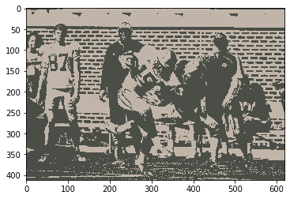

```python
start_time_k2_fb = time.time()
distances,means,labels,iterations = kmed.K_medoids('football.bmp',k=2,iter_max=50,distance='manhatten',text_updated=False,random_means_init=True,mannual_centroid_array=None,delta_halt=True,delta_min=.001,down_sample=True,down_percent=.3,show_images=False)
end_time_k2_fb = time.time()
total_time_k2_fb = round(end_time_k2_fb - start_time_k2_fb,2)
```

```
'Total Runtime = 138.4 Seconds'
```

```
'Number of Iterations Until Convergence = 3'
```

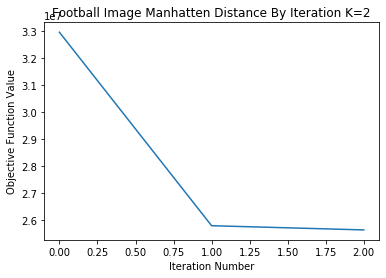

```python
display('Total Runtime = %s Seconds'% total_time_k2_fb)
display('Number of Iterations Until Convergence = %s'% iterations)
plt.plot(np.sum(distances,axis=1))
plt.ylabel('Objective Function Value')
plt.xlabel('Iteration Number')
plt.title('Football Image Manhatten Distance By Iteration K=2')
plt.show()
```

### K-Medoids Implementation using the Football Image with K=16

```
------ Initial Image -------
```

```
------- Image Based on Random Centers and Assignment  -------
```

[figure not shown]

```
------The Medoids have reached convergence distance at min delta during iteration 7 ------
```

[figure not shown]

```python
start_time_k16_fb = time.time()
distances1,means1,labels1,iterations1 = kmed.K_medoids('football.bmp',k=16,iter_max=50,distance='manhatten',text_updated=False,random_means_init=True,mannual_centroid_array=None,delta_halt=True,delta_min=.001,down_sample=True,down_percent=.3,show_images=False)
end_time_k16_fb = time.time()
total_time_k16_fb = round(end_time_k16_fb - start_time_k16_fb,2)
```

```
Total Runtime = 45.67 Seconds
Number of Iterations Until Convergence = 8
```

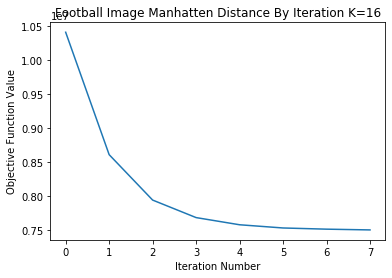

```python
print('Total Runtime = %s Seconds'% total_time_k16_fb)
print('Number of Iterations Until Convergence = %s'% iterations1)
plt.plot(np.sum(distances1,axis=1))
plt.ylabel('Objective Function Value')
plt.xlabel('Iteration Number')
plt.title('Football Image Manhatten Distance By Iteration K=16')
plt.show()
```

### K-Medoids Implementation using the Football Image with K=32

```
------ Initial Image -------
```

```
------- Image Based on Random Centers and Assignment  -------
```

[figure not shown]

```
------The Medoids have reached convergence distance at min delta during iteration 12 ------
```

[figure not shown]

```python
start_time_k32_fb = time.time()
distances2,means2,labels2,iterations2 = kmed.K_medoids('football.bmp',k=32,iter_max=50,distance='manhatten',text_updated=False,random_means_init=True,mannual_centroid_array=None,delta_halt=True,delta_min=.001,down_sample=True,down_percent=.3,show_images=False)
end_time_k32_fb = time.time()
total_time_k32_fb = round(end_time_k32_fb - start_time_k32_fb,2)
```

```
Total Runtime = 42.82 Seconds
Number of Iterations Until Convergence = 13
```

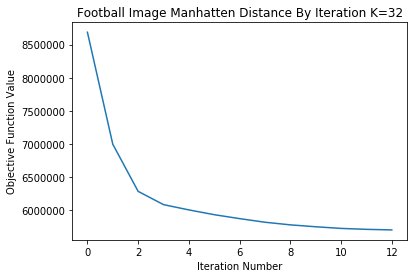

```python
print('Total Runtime = %s Seconds'% total_time_k32_fb)
print('Number of Iterations Until Convergence = %s'% iterations2)
plt.plot(np.sum(distances2,axis=1))
plt.ylabel('Objective Function Value')
plt.xlabel('Iteration Number')
plt.title('Football Image Manhatten Distance By Iteration K=32')
plt.show()
```

### K-Medoids Implementation using the Beach Image with K=2

```
------ Initial Image -------
```

```
------- Image Based on Random Centers and Assignment  -------
```

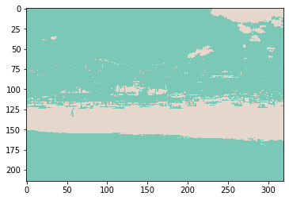

```
------The Medoids have reached convergence distance at min delta during iteration 2 ------
```

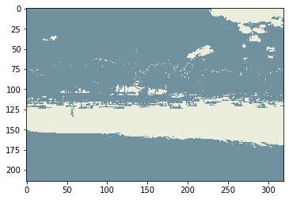

```python
start_time_k2_beach = time.time()
distancesb,meansb,labelsb,iterationsb = kmed.K_medoids('beach.bmp',k=2,iter_max=50,distance='ecludian',text_updated=False,random_means_init=True,mannual_centroid_array=None,delta_halt=True,delta_min=.001,down_sample=True,down_percent=.3,show_images=False)
end_time_k2_beach  = time.time()
total_time_k2_beach  =   round(end_time_k2_beach - start_time_k2_beach)
```

```
Total Runtime = 13 Seconds
Number of Iterations Until Convergence = 3
```

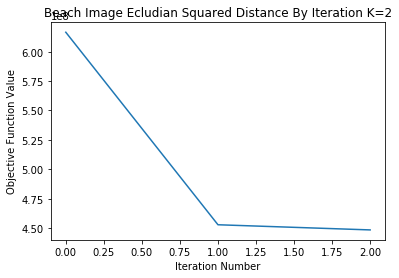

```python
print('Total Runtime = %s Seconds'% total_time_k2_beach)
print('Number of Iterations Until Convergence = %s'% iterationsb)
plt.plot(np.sum(distancesb,axis=1))
plt.ylabel('Objective Function Value')
plt.xlabel('Iteration Number')
plt.title('Beach Image Ecludian Squared Distance By Iteration K=2')
plt.show()
```

### K-Medoids Implementation using the Beach Image with K=16

```
------ Initial Image -------
```

```
------- Image Based on Random Centers and Assignment  -------
```

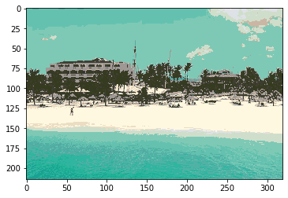

```
------The Medoids have reached convergence distance at min delta during iteration 24 ------
```

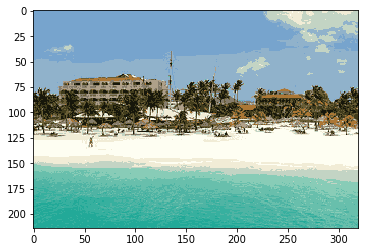

```python
start_time_k16_beach = time.time()
distancesb1,meansb1,labelsb1,iterationsb1 = kmed.K_medoids('beach.bmp',k=16,iter_max=50,distance='ecludian',text_updated=False,random_means_init=True,mannual_centroid_array=None,delta_halt=True,delta_min=.001,down_sample=True,down_percent=.3,show_images=False)
end_time_k16_beach  = time.time()
total_time_k16_beach  =  round(end_time_k16_beach - start_time_k16_beach)
```

```
Total Runtime = 8 Seconds
Number of Iterations Until Convergence = 25
```

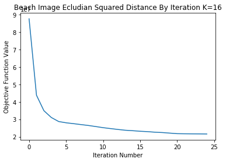

```python
print('Total Runtime = %s Seconds'% total_time_k16_beach )
print('Number of Iterations Until Convergence = %s'% iterationsb1)
plt.plot(np.sum(distancesb1,axis=1))
plt.ylabel('Objective Function Value')
plt.xlabel('Iteration Number')
plt.title('Beach Image Ecludian Squared Distance By Iteration K=16')
plt.show()
```

### K-Medoids Implementation using the Beach Image with K=32

```
------ Initial Image -------
```

```
------- Image Based on Random Centers and Assignment  -------
```

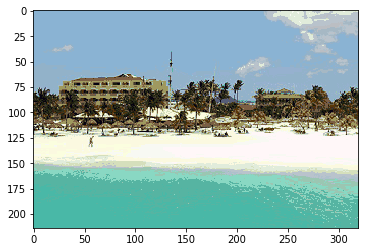

```
------The Medoids have reached convergence distance at min delta during iteration 17 ------
```

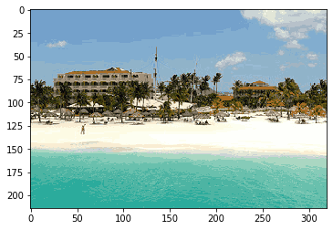

```python
start_time_k32_beach = time.time()
distancesb2,meansb2,labelsb2,iterationsb2 = kmed.K_medoids('beach.bmp',k=32,iter_max=50,distance='ecludian',text_updated=False,random_means_init=True,mannual_centroid_array=None,delta_halt=True,delta_min=.001,down_sample=True,down_percent=.3,show_images=False)
end_time_k32_beach  = time.time()
total_time_k32_beach  =  round(end_time_k32_beach - start_time_k32_beach,2)
```

```
Total Runtime = 5.19 Seconds
Number of Iterations Until Convergence = 18
```

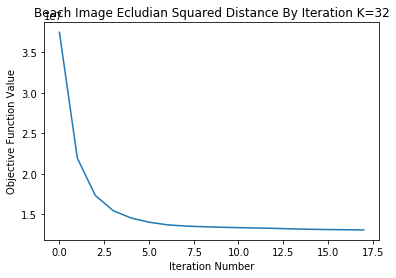

```python
print('Total Runtime = %s Seconds'% total_time_k32_beach)
print('Number of Iterations Until Convergence = %s'% iterationsb2)
plt.plot(np.sum(distancesb2,axis=1))
plt.ylabel('Objective Function Value')
plt.xlabel('Iteration Number')
plt.title('Beach Image Ecludian Squared Distance By Iteration K=32')
plt.show()
```

### K-Medoids Implementation using the French Fry Image with K=2

```
------ Initial Image -------
```

```
------- Image Based on Random Centers and Assignment  -------
```

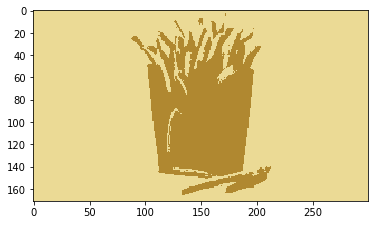

```
------The Medoids have reached convergence algorithim halted during iteration 2 ------
```

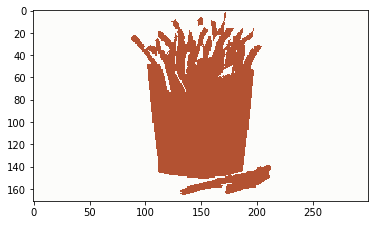

```python
start_time_k2_fries = time.time()
distances_fries,means_fries,labels_fries,iterations_fries = kmed.K_medoids('fries.jpg',k=2,iter_max=50,distance='ecludian',text_updated=False,random_means_init=True,mannual_centroid_array=None,delta_halt=True,delta_min=.001,down_sample=True,down_percent=.3,show_images=False)
end_time_k2_fries  = time.time()
total_time_k2_fries  =  round(end_time_k2_fries - start_time_k2_fries,2)
```

```
Total Runtime = 3.25 Seconds
Number of Iterations Until Convergence = 3
```

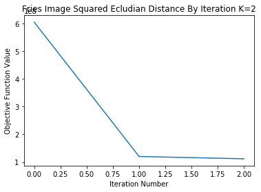

```python
print('Total Runtime = %s Seconds'% total_time_k2_fries)
print('Number of Iterations Until Convergence = %s'% iterations_fries)
plt.plot(np.sum(distances_fries,axis=1))
plt.ylabel('Objective Function Value')
plt.xlabel('Iteration Number')
plt.title('Fries Image Squared Ecludian Distance By Iteration K=2')
plt.show()
```

### K-Medoids Implementation using the French Fry Image with K=16

```
------ Initial Image -------
```

```
------- Image Based on Random Centers and Assignment  -------
```

[figure not shown]

```
------The Medoids have reached convergence algorithim halted during iteration 10 ------
```

[figure not shown]

```python
start_time_k16_fries = time.time()
distances_fries2,means_fries2,labels_fries2,iterations_fries2 = kmed.K_medoids('fries.jpg',k=16,iter_max=50,distance='ecludian',text_updated=False,random_means_init=True,mannual_centroid_array=None,delta_halt=True,delta_min=.001,down_sample=True,down_percent=.3,show_images=False)
end_time_k16_fries  = time.time()
total_time_k16_fries  =  round(end_time_k16_fries - start_time_k16_fries,2)
```

```
Total Runtime = 1.97 Seconds
Number of Iterations Until Convergence = 11
```

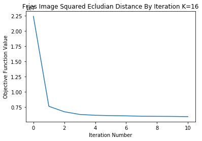

```python
print('Total Runtime = %s Seconds'% total_time_k16_fries)
print('Number of Iterations Until Convergence = %s'% iterations_fries2)
plt.plot(np.sum(distances_fries2,axis=1))
plt.ylabel('Objective Function Value')
plt.xlabel('Iteration Number')
plt.title('Fries Image Squared Ecludian Distance By Iteration K=16')
plt.show()
```

### K-Medoids Implementation using the French Fry Image with K=32

```
------ Initial Image -------
```

```
------- Image Based on Random Centers and Assignment  -------
```

[figure not shown]

```
------The Medoids have reached convergence distance at min delta during iteration 11 ------
```

[figure not shown]

```python
start_time_k32_fries = time.time()
distances_fries3,means_fries3,labels_fries3,iterations_fries3 = kmed.K_medoids('fries.jpg',k=32,iter_max=50,distance='ecludian',text_updated=False,random_means_init=True,mannual_centroid_array=None,delta_halt=True,delta_min=.001,down_sample=True,down_percent=.3,show_images=False)
end_time_k32_fries  = time.time()
total_time_k32_fries  = round(end_time_k32_fries - start_time_k32_fries,2)
```

```
Total Runtime = 1.95 seconds
Number of Iterations Until Convergence = 12
```

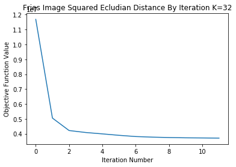

```python
print('Total Runtime = %s seconds'% total_time_k32_fries)
print('Number of Iterations Until Convergence = %s'% iterations_fries3)
plt.plot(np.sum(distances_fries3,axis=1))
plt.ylabel('Objective Function Value')
plt.xlabel('Iteration Number')
plt.title('Fries Image Squared Ecludian Distance By Iteration K=32')
plt.show()
```

### K Parameter Tuning Using The Football Image and Manhatten Distance:

Below I have implemented another function that sweeps over various values for k until convergence then reports each k-values respective final total inter-cluster distance, run-time, and iterations required to converge. Again, given the usage of medoids and the computationally expensive nature it imposes each run has halting conditions for distance improvement and uses down sampling. Due to these practicalities, the distance metric for each given k will not be guaranteed to be even a local minimum as the whole solution space for each cluster center was not searched. Also, the values of distance iteration to consecutive iteration must have decreased by specified thresholds which confound results in distance, runtime, and number of iterations until convergence. With these warnings in mind the data still provides some interesting information in the form of a generalized elbow plot, and some of the general behavior of the algorithm.

```python
k_distance_list,times_list,k_indexes,number_of_iterations_required = kmed.sweep_k_values('football.bmp',iter_max=25,start_k=2,end_k=100,distance='manhatten',delta_halt=True,delta_min=.001,down_sample=True,down_percent=.01,show_images=False)
```

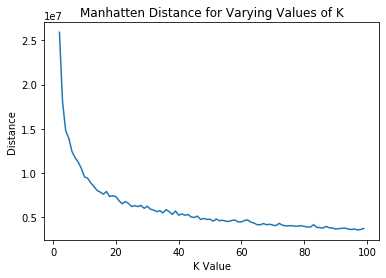

```python
df_distances =pd.DataFrame(k_distance_list,index=k_indexes,columns=['Distance'])
plt.plot(df_distances)
plt.xlabel('K Value')
plt.ylabel('Distance')
plt.title('Manhatten Distance for Varying Values of K')
plt.show()
```

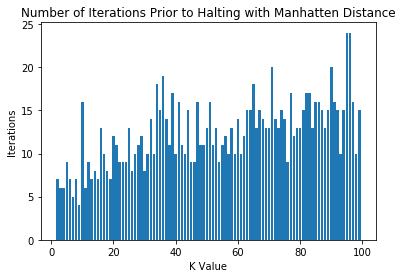

```python
plt.bar(k_indexes,number_of_iterations_required)
plt.title('Number of Iterations Prior to Halting with Manhatten Distance')
plt.ylabel('Iterations')
plt.xlabel('K Value')
plt.show()
```

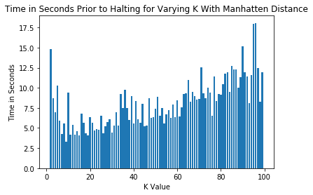

```python
plt.bar(k_indexes,times_list)
plt.title('Time in Seconds Prior to Halting for Varying K With Manhatten Distance')
plt.ylabel('Time in Seconds')
plt.xlabel('K Value')
plt.show()
```

### Additional Documentation

- Module/Package Call: import custom_k_medoids as kmed
- Primary Function: kmed.K_medoids()
- Required Arguments:
  - initial_image_path: the location of your test image of choice as a string. If within folder of the notebook just specific image name as a string with proper file ending.
  - k: the desired number of clusters for the algorithm to solve for. Default is set to 3.
- Optional Arguments:
  - iter_max: the number of maximum iterations to perform on a given run. This argument takes an intger as input and defaults to 20 if no argument is given.
  - distance: takes a string in the form of 'Euclidian' (for squared Euclidian distance) or 'Manhattan' for L1 norm as the distance function used argument default is Euclidian.
  - text_updated: Defaults to False. If specified as true, the user can see, by operation, assignment data and other related metrics. Beware this is a lot of printed text output.
  - random_means_init: Defaults to True. Causes our medoids initial centroids to be chosen at random from unique points within the data set. Implementation relies on NumPy choice function. If set to False allows manual center assignment.
  - mannual_centroid_array: defaults to None allows user to input manual initial centers. If random_means_init is specified as False and a NumPy array of shape matching k shape is provided to this argument the specified centers will be used for algorithm initialization. If shapes do not match, the function will return error limited feedback on input.
  - delta_halt: Default value is False. If True, allows the user to specific a mandatory distance improvement threshold for consecutive iterations in latter optional argument.
  - delta_min: Defaults to .001 when prior is set to True and None when prior is set to False. The decimal determines what percentage gain in improvement we must see iteration over iteration to justify continuing the algorithm or halting if not met.
  - down_sample: Defaults to False. If set to True, allows the down_percent argument to be set to a decimal number. If False prevents down-sampling in centroid recalculation.
  - down_percent: Defaults to .5 when prior is true and None when prior is false. This argument determines what percentage of unique points within each cluster to sample as a potential new centroid in the re-calculation of means phase of the algorithm
  - show_images: Defaults to True which displays, by iteration, image output. If false the algorithm will still display initial image, initial assignment, and final assignment images.
  - sweep_k: Argument defaults to false. Only for usage within the broader sweep_k function that suppresses text output by iteration when set to true.
- Output:
  - Distance list: consists of a list of NumPy arrays that contain each respective iteration's inter-cluster distances.
  - Centroids: a NumPy array that contains each final cluster centroid.
  - Labels: a NumPy array that contain each observation assigned cluster (indexed by initial image array).
  - Iterations: a numeric output that acts as a counter that keeps track of what iteration number the algorithm halted on.